# Tire Falloff Predictions

Matthew Kirk (mkir489)

2023-06-29

Packages:

```r
library(tidyverse)
library(lubridate)
library(jsonlite)
```

## Project Summary

- Use race laptimes to create predictive tire falloff models for each driver, to use live in future races.
  - Simple glm, using only historic data
- Extension: use this tire model to create simulated pit stop prediction models/visualisations (using D3.js).
- Normalise lap time some how? First lap = 1 or something?

## Data ingest

**TODO:** - Get tire compound data for stints - Add function that flags safety car laps

### Set constants for data

```r
# Laptime Data ------------------------------------------------------------
YEAR = 2023
ROUND = 1
```

### Get Race Laptime Data

```r
# Accesses API and gets value for total rows in full race
laps_total.url <- paste0("https://ergast.com/api/f1/", YEAR, "/", ROUND, "/laps.json")
# Gets total number of rows in full race
total_num <- as.numeric(fromJSON(laps_total.url)$MRData$total)
# Number of loop iterations needed to access full race data (limit = 1000)
iterations_needed <- floor(total_num / 1000)


# Actual loop that gets full race data
laptimes_raw.df <- map_df(0 : iterations_needed, function(i){
  Sys.sleep(0.5)

  # Generate offset
  offset_x = i * 1000

  # Round 1
  r1_laptimes.url <- paste0("https://ergast.com/api/f1/", YEAR, "/", ROUND, "/laps.json?limit=1000&offset=", offset_x)

  # get json from url, navigate json to lap times, then unnest
  r1_lap.df <- unnest(fromJSON(r1_laptimes.url)$MRData$RaceTable$Races$Laps[[1]], cols = c(Timings))

  return(r1_lap.df)
})

head(laptimes_raw.df)
```

```
## # A tibble: 6 × 4
##   number driverId       position time
##   <chr>  <chr>          <chr>    <chr>
## 1 1      max_verstappen 1        1:39.019
## 2 1      leclerc        2        1:40.230
## 3 1      perez          3        1:41.063
## 4 1      sainz          4        1:41.659
## 5 1      hamilton       5        1:42.288
## 6 1      russell        6        1:42.662
```

Now rename ‘number’ to ‘lap’, and convert data into correct types (numeric & datetime)

```r
# Clean laptime data
laptimes_clean.df <- laptimes_raw.df %>%
  rename(lap = number, laptime = time) %>%
  mutate(lap = as.numeric(lap),
         position = as.numeric(position),
         laptime_lub = ms(laptime),
         laptime_seconds = as.numeric(laptime_lub))

head(laptimes_clean.df)
```

```
## # A tibble: 6 × 6
##     lap driverId       position laptime  laptime_lub laptime_seconds
##   <dbl> <chr>             <dbl> <chr>    <Period>              <dbl>
## 1     1 max_verstappen        1 1:39.019 1M 39.019S             99.0
## 2     1 leclerc               2 1:40.230 1M 40.23S             100.
## 3     1 perez                 3 1:41.063 1M 41.063S            101.
## 4     1 sainz                 4 1:41.659 1M 41.659S            102.
## 5     1 hamilton              5 1:42.288 1M 42.288S            102.
## 6     1 russell               6 1:42.662 1M 42.662S            103.
```

Notice, there’s no constructor data associated with with the drivers. We’ll use the driver standings API and join it to this table

### Get Driver/Constructor Data

```r
# Team/Constructor data ---------------------------------------------------

driver_constructors.url <- paste0("http://ergast.com/api/f1/", YEAR, "/driverStandings.json")
driver_constructors_raw.df <- unnest(fromJSON(driver_constructors.url)$MRData$StandingsTable$StandingsLists$DriverStandings[[1]])
# Clean constructor data
# Remove unneeded info from driver_constructors and rename some variables
driver_constructors_clean.df <-  driver_constructors_raw.df%>%
  select(-position, -positionText, -points, -wins, -url, -url1) %>%
  rename(driverNationality = nationality, constructorName = name, constructorNationality = nationality1) %>%
  mutate(dateOfBirth = ymd(dateOfBirth))

head(driver_constructors_clean.df)
```

```
## # A tibble: 6 × 10
##   driverId      perma…¹ code  given…² famil…³ dateOfBi…⁴ drive…⁵ const…⁶ const…⁷
##   <chr>         <chr>   <chr> <chr>   <chr>   <date>     <chr>   <chr>   <chr>
## 1 max_verstapp… 33      VER   Max     Versta… 1997-09-30 Dutch   red_bu… Red Bu…
## 2 perez         11      PER   Sergio  Pérez   1990-01-26 Mexican red_bu… Red Bu…
## 3 alonso        14      ALO   Fernan… Alonso  1981-07-29 Spanish aston_… Aston …
## 4 hamilton      44      HAM   Lewis   Hamilt… 1985-01-07 British merced… Merced…
## 5 sainz         55      SAI   Carlos  Sainz   1994-09-01 Spanish ferrari Ferrari
## 6 russell       63      RUS   George  Russell 1998-02-15 British merced… Merced…
## # … with 1 more variable: constructorNationality <chr>, and abbreviated
## #   variable names ¹permanentNumber, ²givenName, ³familyName, ⁴dateOfBirth,
## #   ⁵driverNationality, ⁶constructorId, ⁷constructorName
```

### Get Pitstop data

```r
# Pitstop Data ------------------------------------------------------------

pitstops.url <- paste0("http://ergast.com/api/f1/", YEAR, "/", ROUND, "/pitstops.json?limit=60")
pitstops_raw.df <- fromJSON(pitstops.url)$MRData$RaceTable$Races$PitStops[[1]]

# Clean pitstop data
pitstops_clean.df <- pitstops_raw.df %>%
  mutate(lap_pitted = as.numeric(lap),
         stop_number = as.numeric(stop),
         pit_duration_secs = as.numeric(duration),
         time_pitted = hms(time)) %>%
  select(-time, -duration, -lap, -stop)

head(pitstops_clean.df)
```

```
##     driverId lap_pitted stop_number pit_duration_secs time_pitted
## 1      gasly          9           1            25.885 18H 18M 56S
## 2     norris         10           1            32.766 18H 20M 31S
## 3    tsunoda         10           1            25.267 18H 20M 34S
## 4     bottas         11           1            25.399  18H 22M 6S
## 5      albon         11           1            25.054 18H 22M 12S
## 6 hulkenberg         11           1            26.075 18H 22M 21S
```

Now create two new dataframes to denote whether a lap was an in-lap or out-lap, as these laps are slower than ‘regular’ laps.

```r
# Create temp df denoting pit in-laps
pitstops_in.df <- pitstops_clean.df %>%
  select(driverId, lap_pitted) %>%
  rename(pit_in_lap = lap_pitted) %>%
  mutate(is_in_lap = 1)


# Create temp df denoting pit out-laps
pitstops_out.df <- pitstops_in.df %>%
  mutate(pit_out_lap = pit_in_lap + 1) %>%
  rename(is_out_lap = is_in_lap) %>%
  select(-pit_in_lap) %>%
  relocate(is_out_lap, .after = pit_out_lap)

head(pitstops_in.df)
```

```
##     driverId pit_in_lap is_in_lap
## 1      gasly          9         1
## 2     norris         10         1
## 3    tsunoda         10         1
## 4     bottas         11         1
## 5      albon         11         1
## 6 hulkenberg         11         1
```

```r
head(pitstops_out.df)
```

```
##     driverId pit_out_lap is_out_lap
## 1      gasly          10          1
## 2     norris          11          1
## 3    tsunoda          11          1
## 4     bottas          12          1
## 5      albon          12          1
## 6 hulkenberg          12          1
```

### Join Driver/Constructor, Pitstops tables to main laptime table

```r
# Join teams
laptimes_constructor.df <- laptimes_clean.df %>%
  left_join(driver_constructors_clean.df, by="driverId")

head(laptimes_constructor.df)
```

```
## # A tibble: 6 × 15
##     lap drive…¹ posit…² laptime laptime_…³ lapti…⁴ perma…⁵ code  given…⁶ famil…⁷
##   <dbl> <chr>     <dbl> <chr>   <Period>     <dbl> <chr>   <chr> <chr>   <chr>
## 1     1 max_ve…       1 1:39.0… 1M 39.019S    99.0 33      VER   Max     Versta…
## 2     1 leclerc       2 1:40.2… 1M 40.23S    100.  16      LEC   Charles Leclerc
## 3     1 perez         3 1:41.0… 1M 41.063S   101.  11      PER   Sergio  Pérez
## 4     1 sainz         4 1:41.6… 1M 41.659S   102.  55      SAI   Carlos  Sainz
## 5     1 hamilt…       5 1:42.2… 1M 42.288S   102.  44      HAM   Lewis   Hamilt…
## 6     1 russell       6 1:42.6… 1M 42.662S   103.  63      RUS   George  Russell
## # … with 5 more variables: dateOfBirth <date>, driverNationality <chr>,
## #   constructorId <chr>, constructorName <chr>, constructorNationality <chr>,
## #   and abbreviated variable names ¹driverId, ²position, ³laptime_lub,
## #   ⁴laptime_seconds, ⁵permanentNumber, ⁶givenName, ⁷familyName
```

```r
# Join pitstops
laptimes_constructor_pits.df <- laptimes_constructor.df %>%
  left_join(pitstops_in.df,
            by = join_by(driverId == driverId, lap == pit_in_lap)) %>%
  left_join(pitstops_out.df,
            by = join_by(driverId == driverId, lap == pit_out_lap))

head(laptimes_constructor_pits.df)
```

```
## # A tibble: 6 × 17
##     lap drive…¹ posit…² laptime laptime_…³ lapti…⁴ perma…⁵ code  given…⁶ famil…⁷
##   <dbl> <chr>     <dbl> <chr>   <Period>     <dbl> <chr>   <chr> <chr>   <chr>
## 1     1 max_ve…       1 1:39.0… 1M 39.019S    99.0 33      VER   Max     Versta…
## 2     1 leclerc       2 1:40.2… 1M 40.23S    100.  16      LEC   Charles Leclerc
## 3     1 perez         3 1:41.0… 1M 41.063S   101.  11      PER   Sergio  Pérez
## 4     1 sainz         4 1:41.6… 1M 41.659S   102.  55      SAI   Carlos  Sainz
## 5     1 hamilt…       5 1:42.2… 1M 42.288S   102.  44      HAM   Lewis   Hamilt…
## 6     1 russell       6 1:42.6… 1M 42.662S   103.  63      RUS   George  Russell
## # … with 7 more variables: dateOfBirth <date>, driverNationality <chr>,
## #   constructorId <chr>, constructorName <chr>, constructorNationality <chr>,
## #   is_in_lap <dbl>, is_out_lap <dbl>, and abbreviated variable names
## #   ¹driverId, ²position, ³laptime_lub, ⁴laptime_seconds, ⁵permanentNumber,
## #   ⁶givenName, ⁷familyName
```

Now replace the NAs in ‘is_in_lap’ and ‘is_out_lap’ with 0’s

```r
# Remove NAs
laptimes_constructor_pits.df <- laptimes_constructor_pits.df %>%
  mutate(is_in_lap = ifelse(is.na(is_in_lap), 0, 1),
         is_out_lap = ifelse(is.na(is_out_lap), 0, 1))

head(laptimes_constructor_pits.df)
```

```
## # A tibble: 6 × 17
##     lap drive…¹ posit…² laptime laptime_…³ lapti…⁴ perma…⁵ code  given…⁶ famil…⁷
##   <dbl> <chr>     <dbl> <chr>   <Period>     <dbl> <chr>   <chr> <chr>   <chr>
## 1     1 max_ve…       1 1:39.0… 1M 39.019S    99.0 33      VER   Max     Versta…
## 2     1 leclerc       2 1:40.2… 1M 40.23S    100.  16      LEC   Charles Leclerc
## 3     1 perez         3 1:41.0… 1M 41.063S   101.  11      PER   Sergio  Pérez
## 4     1 sainz         4 1:41.6… 1M 41.659S   102.  55      SAI   Carlos  Sainz
## 5     1 hamilt…       5 1:42.2… 1M 42.288S   102.  44      HAM   Lewis   Hamilt…
## 6     1 russell       6 1:42.6… 1M 42.662S   103.  63      RUS   George  Russell
## # … with 7 more variables: dateOfBirth <date>, driverNationality <chr>,
## #   constructorId <chr>, constructorName <chr>, constructorNationality <chr>,
## #   is_in_lap <dbl>, is_out_lap <dbl>, and abbreviated variable names
## #   ¹driverId, ²position, ³laptime_lub, ⁴laptime_seconds, ⁵permanentNumber,
## #   ⁶givenName, ⁷familyName
```

### Denote if first lap

The first lap of a race is significantly slower than the rest of the race, especially for cars who qualified further down the field. This could be a useful indicator.

```r
laptimes_constructor_pits.df <- laptimes_constructor_pits.df %>%
  mutate(is_first_lap = ifelse(lap == 1, 1, 0))
```

### Get previous lap time

The previous lap time will probably be very predictive of subsequent laptimes

```r
laptimes_constructor_pits.df <- laptimes_constructor_pits.df %>%
  arrange(driverId, lap) %>%
  mutate(prev_laptime_seconds = ifelse(is_first_lap != 1, lag(laptime_seconds), NA)) %>%
  arrange(lap, position)
```

### Flag safety car laps

**TODO**

Safety cars occur when there’s been an incident on track (crashed or broken down car, for example). These lap times are significantly slower than normal ‘racing’ laps.

Therefore we need to flag if a lap is under a safety car.

If laptimes are more 10% slower than median lap times (for a driver?), then flag them as safety car laps NOTE: This might need to be re-worked as it may not perfectly flag yellow flags

```r
# if laptime > median(laptimes) AND not in/out lap ()
sc_cutoff <- median(laptimes_constructor_pits.df$laptime_seconds) * 1.1
```

### Create tire age variable

At the moment, I am assuming all cars are starting on new tires, as there’s no way for me to track if a specific set of tires has been used earlier in the weekend.

This will break if someone pits and doesnt change tires (extremely unlikely that this happens)

```r
# Simplifed DF for PT
tire_age.df <- laptimes_constructor_pits.df %>%
  arrange(driverId, lap) %>%
  mutate(tire_age = 1) %>%
  group_by(driverId) %>%
  mutate(stint = cumsum(is_out_lap)) %>%
  ungroup() %>%
  group_by(driverId, stint) %>%
  mutate(tire_age = cumsum(tire_age)-1) %>%
  ungroup() %>%
  arrange(lap, position) %>%
  relocate(tire_age, .after = lap)
```

## Analysis

###Test Chart

Lap times

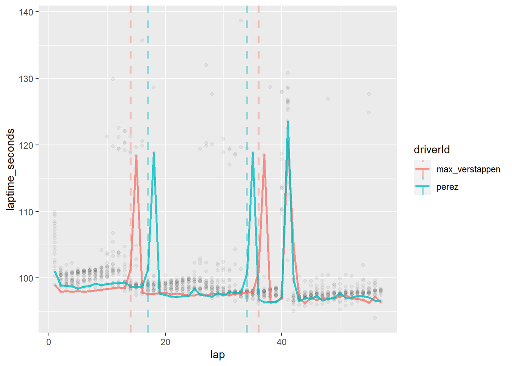

```r
redbull_pits <- laptimes_constructor_pits.df %>%
  filter(constructorId == "red_bull", is_in_lap == 1)

redbull_times.df <- laptimes_constructor_pits.df %>%
  filter(constructorId == "red_bull")

ggplot() +
  geom_point(aes(x=lap, y = laptime_seconds, group = driverId),
             data=laptimes_constructor_pits.df,
             alpha = 0.05) +
  geom_line(aes(x=lap, y = laptime_seconds, group = driverId, colour = driverId),
             data=redbull_times.df,
             alpha = 0.8, size = 1) +
  geom_vline(aes(xintercept = lap, color = driverId), data = redbull_pits, lty = 2, alpha = 0.4, size = 1)
```

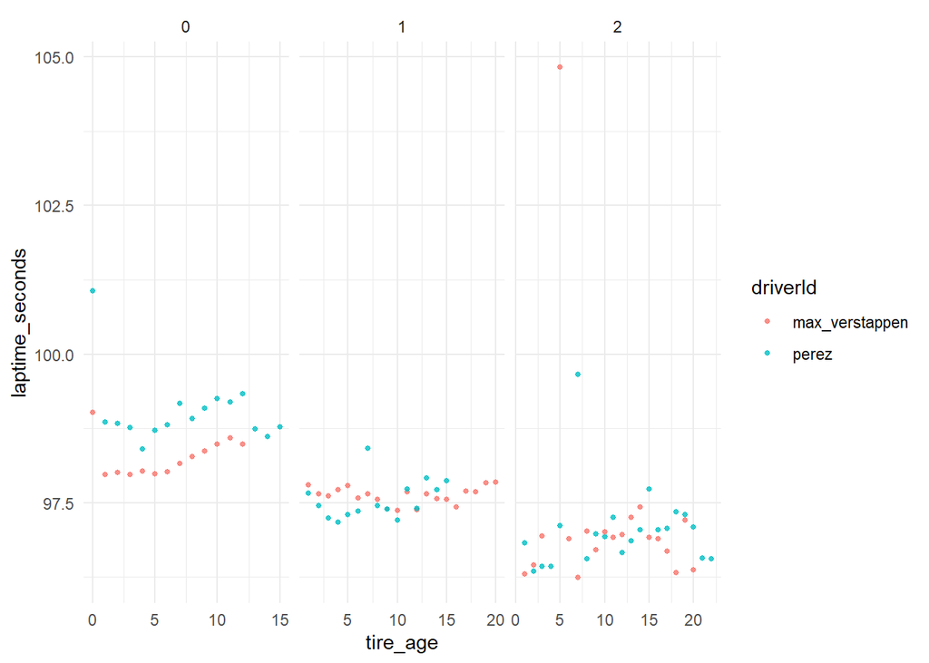

```r
tire_age.df %>%
  filter(constructorId == "red_bull",
         laptime_seconds < sc_cutoff,
         is_in_lap == 0) %>%
  ggplot(aes(x = tire_age, y = laptime_seconds, group = driverId, color = driverId)) +
  geom_point(alpha = 0.8, size = 1) +
  # geom_line(stat = "smooth", se = F, size = 1, alpha = 0.4) +
  facet_wrap(vars(stint), scales = "free_x") +
  theme_minimal()
```

## Resources

- [Ergast F1 API](http://ergast.com/mrd/) for historical data (i.e. not live)
- FastF1 API wrapper [docs](https://docs.fastf1.dev/examples/index.html) [github](https://github.com/theOehrly/Fast-F1)

## Notes:

### Tire Falloff Model:

- Extract lap times from Ergast F1 data.
  - Remove non-racing laps (safety cars/outlaps to restart, laptimes a certain percentage above median laptime?)
- Combine with pitstop data to determine when tires changed
- Get tire data for each stint.
  - Manually input data to start with
  - Way to scrape the data?

### Model factors

- numeric:
  - Laps on tire
- factor:
  - Driver
  - Team
  - Tire Compound
  - Track/Track type? (Is there some objective)
    - Including track would be over-fitting? Track type would work better if exists
    - Street circuit?
  - Temperature? weather? (
- other:
  - Increased weight to more recent races?
    - Car development means tire falloff is not constant. Teams will generally make changes to car to improve tire wear over time.
    - Maybe there’s a better way to account for this?

### Live data - Predictions

- Use fastF1 python wrapper
  - Not possible to do realtime processing of data with FastF1
  - Live export data to database and then query that.
  - [This live dashboard does exactly that](https://github.com/f1stuff/f1-live-data)
- https://www.sportmonks.com/formula-one-api/ ~$100 month
- Scrape timings and tire data from F1tv.
- Use that to fit into model.
- Feed new data into model to get updated tire falloff prediction?
- Use race sim data from practice sessions?